# Assignment 3

Steve Hawley

December 12, 2018

## Section 0: Load the data and packages

```r
library(tidyverse) #for data management
library(foreign) #for importing spss data
library(car) #for leven's test
library(sjstats) #for eta squared
library(effects) #for adjusted means in ancova
library(BaylorEdPsych) #for logisitic regression effect size
#library(QuantPsyc) # For Beta values -- conflicts with dplyr
#library(ppcor) #for pr values -- conflicts with dplyr

# import the spss file. Label the factors
data<-read.spss("Data+for+assignments.sav",to.data.frame = TRUE, add.undeclared.levels = "no")
# take a look at the data. See what the fields are
head(data)
```

|  | code | gender | age | marital | educ | smoke | work | polaff | depress | exer | eat | satcurwt | satwt18 | health | qolcur | qol18 | gift | winter | life | confid |
| --- | --- | --- | --- | --- | --- | --- | --- | --- | --- | --- | --- | --- | --- | --- | --- | --- | --- | --- | --- | --- |
| 1 | 146 | female | 35 | Married | 21 | Never Smoked | Full-Time | Democrat | Sometimes | Rarely | Often | 6 | 5 | 7 | generally satisfied, pleased | generally satisfied, pleased | invest it with brokerage firm | beachfront condo in Hawaii | 87 | 56 |
| 2 | 147 | male | 37 | Married | 18 | Never Smoked | Full-Time | Independent | Sometimes | Sometimes | Often | 3 | 3 | 7 | generally satisfied, pleased | generally satisfied, pleased | invest it with brokerage firm | beachfront condo in Hawaii | 83 | 65 |
| 3 | 148 | female | 43 | Married | 22 | Never Smoked | Full-Time | Independent | Rarely | Routinely | Routinely | 9 | 7 | 9 | very happy most of time | very happy most of the time | invest it with brokerage firm | beachfront condo in Hawaii | 97 | 68 |
| 4 | 149 | male | 35 | Married | 20 | Quit Smoking | Full-Time | Democrat | Sometimes | Routinely | Sometimes | 9 | 9 | 10 | very happy most of time | generally satisfied, pleased | invest it with brokerage firm | beachfront condo in Hawaii | 87 | 65 |
| 5 | 150 | female | 35 | Married | 20 | Quit Smoking | Part-Time | Independent | Rarely | Routinely | Routinely | 9 | 4 | 10 | very happy most of time | generally satisfied, pleased | invest it with brokerage firm | beachfront condo in Hawaii | 108 | 72 |
| 6 | 151 | female | 35 | Never Married | 19 | Never Smoked | Part-Time | Independent | Rarely | Routinely | Routinely | 10 | 10 | 9 | very happy most of time | very happy most of the time | invest it with brokerage firm | beachfront condo in Hawaii | 112 | 80 |

```r
#inspect the data types
str(data)
```

```
## 'data.frame':    701 obs. of  20 variables:
##  $ code    : num  146 147 148 149 150 151 152 153 154 155 ...
##  $ gender  : Factor w/ 2 levels "male","female": 2 1 2 1 2 2 2 NA 1 1 ...
##  $ age     : num  35 37 43 35 35 35 43 45 52 69 ...
##  $ marital : Factor w/ 6 levels "Never Married",..: 2 2 2 2 2 1 2 2 2 2 ...
##  $ educ    : num  21 18 22 20 20 19 18 18 18 15 ...
##  $ smoke   : Factor w/ 3 levels "Never Smoked",..: 1 1 1 2 2 1 1 1 1 3 ...
##  $ work    : Factor w/ 3 levels "Unemployed","Part-Time",..: 3 3 3 3 2 2 2 3 2 1 ...
##  $ polaff  : Factor w/ 3 levels "Republican","Democrat",..: 2 3 3 2 3 3 1 1 2 1 ...
##  $ depress : Factor w/ 4 levels "Rarely","Sometimes",..: 2 2 1 2 1 1 1 1 1 3 ...
##  $ exer    : Factor w/ 4 levels "Rarely","Sometimes",..: 1 2 4 4 4 4 2 2 2 2 ...
##  $ eat     : Factor w/ 4 levels "Rarely","Sometimes",..: 3 3 4 2 4 4 4 4 4 2 ...
##  $ satcurwt: num  6 3 9 9 9 10 2 7 7 6 ...
##   ..- attr(*, "value.labels")= Named chr  "10" "1"
##   .. ..- attr(*, "names")= chr  "Very Satisfied" "Very Dissatisfied"
##  $ satwt18 : num  5 3 7 9 4 10 8 9 9 9 ...
##   ..- attr(*, "value.labels")= Named chr  "10" "1"
##   .. ..- attr(*, "names")= chr  "Very Satisfied" "Very Dissatisfied"
##  $ health  : num  7 7 9 10 10 9 9 8 8 5 ...
##   ..- attr(*, "value.labels")= Named chr  "10" "1"
##   .. ..- attr(*, "names")= chr  "Very Healthy" "Very Sick"
##  $ qolcur  : Factor w/ 6 levels "very dissatisfied, unhappy most of time",..: 4 4 5 5 5 5 5 5 5 3 ...
##  $ qol18   : Factor w/ 6 levels "very dissatisfied, unhappy most of time",..: 4 4 5 4 4 5 4 4 3 5 ...
##  $ gift    : Factor w/ 4 levels "invest it with brokerage firm",..: 1 1 1 1 1 1 2 1 2 1 ...
##  $ winter  : Factor w/ 4 levels "beachfront condo in Hawaii",..: 1 1 1 1 1 1 1 1 3 4 ...
##  $ life    : num  87 83 97 87 108 112 102 103 107 56 ...
##  $ confid  : num  56 65 68 65 72 80 73 77 83 35 ...
##  - attr(*, "variable.labels")= Named chr  "subject's identification number" "gender" "subject's age" "marital status" ...
##   ..- attr(*, "names")= chr  "code" "gender" "age" "marital" ...
##  - attr(*, "codepage")= int 1252
```

## Section 1: ANCOVA

#### **Research Question:** Is there a difference in confidence between males and females when we control for overall life satisfaction?

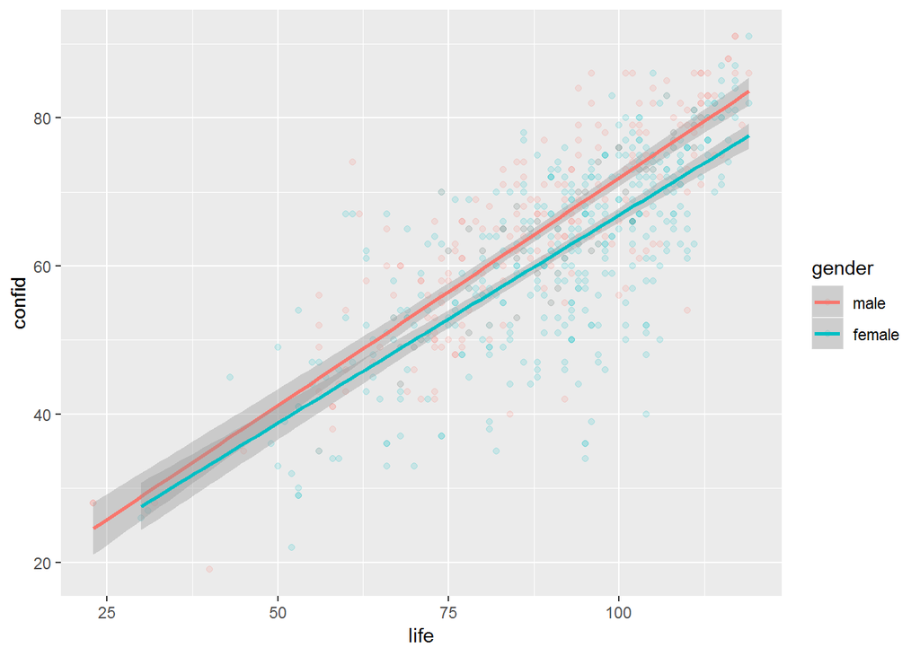

```r
#reference: http://faculty.missouri.edu/huangf/data/quantf/ancova_in_r_handout.pdf

#subset the data for analysis
anc<-data %>%
  select(gender, life, confid) %>%
  drop_na(gender, life, confid)

#plot to look at homogeneity of regression
ggplot(anc, aes(x=life, y=confid, color=gender)) +
  geom_point(alpha = 0.15) +
  geom_smooth(method = "lm")
```

```r
#slopes look reasonably parellel

#Check descriptives
anc %>%
  group_by(gender) %>%
  summarize(mean = mean(confid),
            sd = sd(confid),
            n = n())
```

| gender | mean | sd | n |
| --- | --- | --- | --- |
| male | 64.64082 | 13.04035 | 245 |
| female | 61.74209 | 12.81716 | 411 |

```r
t.test(life~gender, data = anc)
```

```
##
##  Welch Two Sample t-test
##
## data:  life by gender
## t = -1.8918, df = 491.45, p-value = 0.05911
## alternative hypothesis: true difference in means is not equal to 0
## 95 percent confidence interval:
##  -5.3629651  0.1015519
## sample estimates:
##   mean in group male mean in group female
##             88.16735             90.79805
```

```r
#t test is n.s. genders are not different on covariate

leveneTest(anc$confid,anc$gender, center = mean)
```

|  | Df | F value | Pr(>F) |
| --- | --- | --- | --- |
| group | 1 | 0.06862114 | 0.7934376 |
|  | 654 | NA | NA |

```r
#levene's is n.s. therefore assumption of homogeneity of variance is met

#test to look for equality of slopes
mod1 <- aov(confid~gender + life + gender:life, data = anc)
summary(mod1)
```

```
##              Df Sum Sq Mean Sq F value  Pr(>F)
## gender        1   1290    1290  18.902 1.6e-05 ***
## life          1  64231   64231 941.329 < 2e-16 ***
## gender:life   1    127     127   1.855   0.174
## Residuals   652  44489      68
## ---
## Signif. codes:  0 '***' 0.001 '**' 0.01 '*' 0.05 '.' 0.1 ' ' 1
```

```r
EtaSq(mod1)
```

```
##                   Eta^2 Partial Eta^2
## gender      0.011710762   0.028174269
## life        0.583196174   0.590793828
## gender:life 0.001149316   0.002837165
```

```r
#interaction of gender:life is n.s. so the slope across groups is not different

mod2 <- aov(confid~life + gender, data = anc)
summary(mod2)
```

```
##              Df Sum Sq Mean Sq F value   Pr(>F)
## life          1  62522   62522   915.1  < 2e-16 ***
## gender        1   2999    2999    43.9 7.25e-11 ***
## Residuals   653  44616      68
## ---
## Signif. codes:  0 '***' 0.001 '**' 0.01 '*' 0.05 '.' 0.1 ' ' 1
```

```r
#effect size. Don't need to report results for covariate
EtaSq(mod2)
```

```
##                  Eta^2 Partial Eta^2
## life        0.56767656    0.58356732
## gender      0.02723038    0.06298613
```

```r
#adjusted means
effect("gender", mod2)
```

```
##
##  gender effect
## gender
##     male   female
## 65.60183 61.16923
```

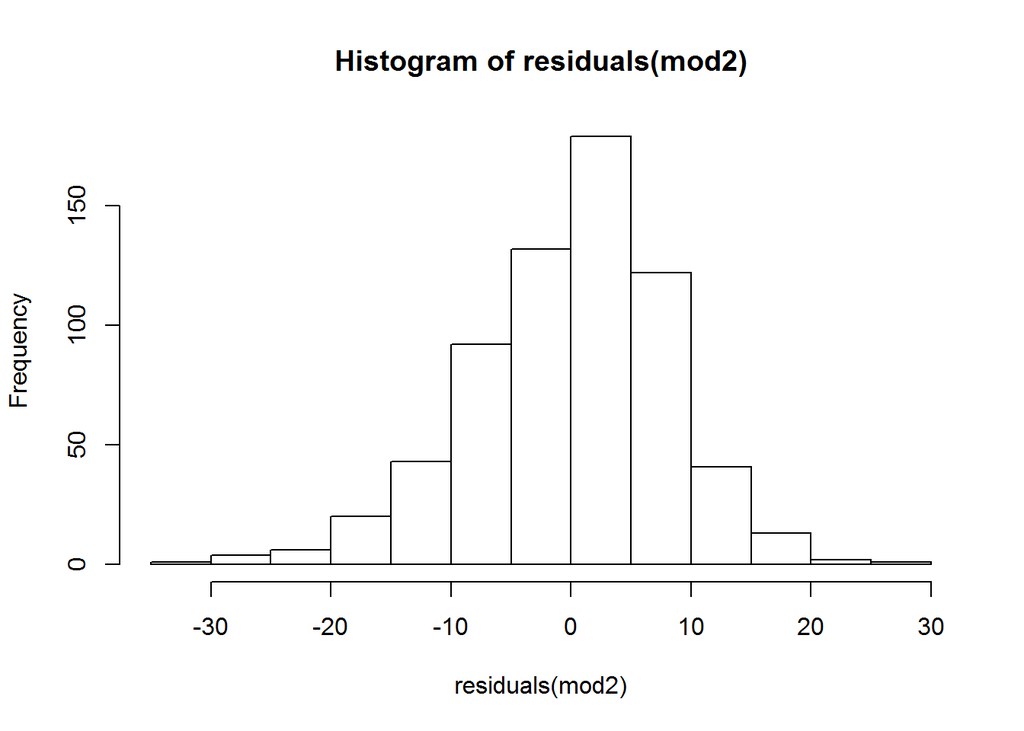

```r
#CHECKING ASSUMPTIONS

hist(residuals(mod2))
```

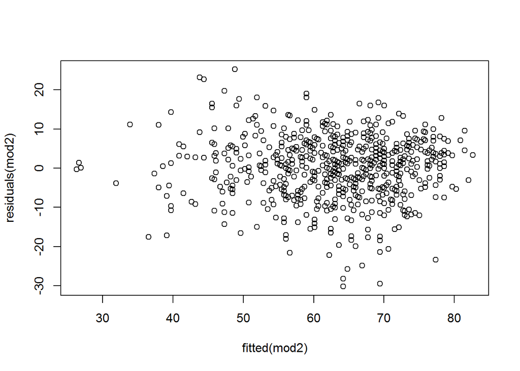

```r
#histogram of residuals in normal

plot(fitted(mod2), residuals(mod2))
```

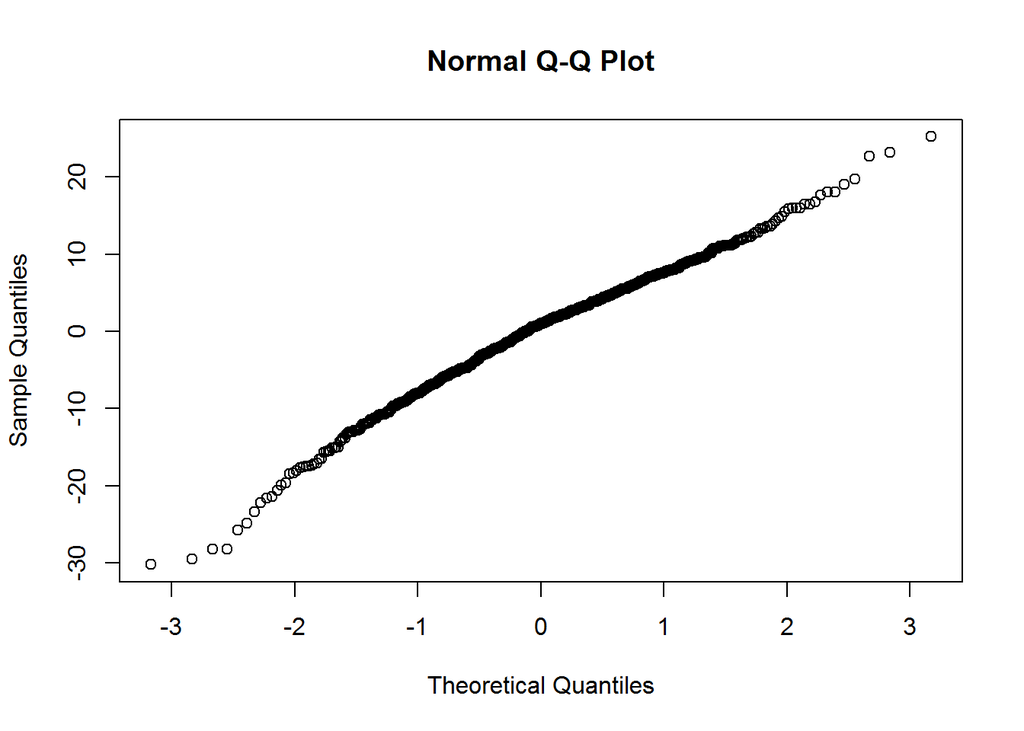

```r
qqnorm(residuals(mod2))
```

```r
##########Alternative approach###########
mod1 <- lm(data = anc, confid~life + gender + life:gender)
Anova(mod1, type = "II")
```

|  | Sum Sq | Df | F value | Pr(>F) |
| --- | --- | --- | --- | --- |
| life | 64231.384 | 1 | 941.328853 | 1.263636e-128 |
| gender | 2999.068 | 1 | 43.952178 | 7.062098e-11 |
| life:gender | 126.582 | 1 | 1.855095 | 1.736624e-01 |
| Residuals | 44489.088 | 652 | NA | NA |

```r
#Interaction is not significant, so the slope across groups is not different
mod2 <- lm(data = anc, confid~life + gender)
Anova(mod2, type = "II")
```

|  | Sum Sq | Df | F value | Pr(>F) |
| --- | --- | --- | --- | --- |
| life | 64231.384 | 1 | 940.0978 | 1.397622e-128 |
| gender | 2999.068 | 1 | 43.8947 | 7.251217e-11 |
| Residuals | 44615.670 | 653 | NA | NA |

##### Results (APA style)

To investigate whether gender has any effect on confidence, a one-way ANCOVA was conducted. The independant variable, gender, included two levels, male and female. The dependant variable was a confidence score from a self reported assessment and the covariate was a life satisfaction score. A preliminary analysis evaluating the homogeneity-of-slopes assumption indicated that the relationship between the covariate and the dependent variable did not differe significantly as a function of the independent variable, F(1,652) = 1.855, MSE = 127, p = 0.174, partial eta_squared = 0.003. The ANCOVA was significant, F(1,653) = 43.9, MSE = 2999, p <0.01, partial eta_squared = 0.06. The strength of relationship between gender and confidence was small, as assessed by partial eta_squared, with the gender accounting for 6% of the variance in the dependent variable, holding life score constant. The means of the confidence scores adjusted for initial differences in life satisfaction scores were ordered in the following way: males (M = 65.60) and females (M = 61.17). Follow up tests were not conducted as gender contained only two factors.